# Countering AntiVaccination Attitudes Replication

Derek Powell & Kara Weisman

**NOTE: These are preliminary analyses as of 4/9/18, 10:55 AM**

This is an R notebook to analyze the data from the Countering AntiVaccination Attitudes (CAVA) replication study. This replication roject was [preregistered on OSF](https://osf.io/j5n4e/) and all data and code are available on [github](https://github.com/derekpowell/cava-rep).

- Part 1 of the study was conducted on March 21, 2018
- Part 2 of the study was conducted on March 22, 2018 (with a few Ps collected March 23, 2018)
- Part 3 of the study was conducted March 29, 2018 (with a few Ps collected March 30, 2018)

```r
# load packages
library(tidyverse)
library(brms)
# library(tidybayes)
if (!require(betareg)) {
  install.packages("betareg")
}
library(betareg)
if (!require(effsize)) {
  install.packages("effsize")
}
library(effsize)
# Define some functions ...
read_qualtrics_csv <- function(fname) {
  df <- read.csv(fname, skip = 3, header = F)
  headers <- as.matrix(read.csv(fname, skip = 0, header = F, nrows = 1, as.is = T))
  colnames(df) <- headers
  df <- df[which(df[, "DistributionChannel", ] == "anonymous"), ] # remove survey previews
  total_n <- nrow(df)
  # remove unused qualtrics variables
  remove_cols <- c(
    "RecipientLastdata",
    "RecipientFirstdata",
    "RecipientEmail",
    "Finished",
    "ResponseId",
    "ExternalReference",
    "DistributionChannel",
    "UserLanguage",
    "Status"
  )
  df <- df[, -which(colnames(df) %in% remove_cols)]
  return(df)
}
rescale_beta <- function(x, lower, upper) {
  # rescales onto the open interval (0,1)
  # rescales over theoretical bounds of measurement, specified by "upper" and "lower"
  # based on Smithson & Verkuilen (2006), though this is not as principled as you might think
  # see http://dx.doi.org/10.1037/1082-989X.11.1.54.supp
  N <- length(x)
  res <- (((x - lower) / (upper - lower)) * (N - 1) + .5) / N
  return(as.vector(res))
}
inv_rescale_beta <- function(scaled_x, lower, upper) {
  # inverts rescaling onto the open interval (0,1)
  # assuming original rescaling over theoretical bounds of measurement, specified by "upper" and "lower"
  # based on Smithson & Verkuilen (2006), though this is not as principled as you might think
  # see http://dx.doi.org/10.1037/1082-989X.11.1.54.supp

  N <- length(scaled_x)
  res <- (scaled_x * N - 1/2)/(N-1)
  res <- res * (upper - lower) + lower
  return(as.vector(res))
}
gg_marginal_effects <- function(model, effects, probs=c(0.25, 0.75)) {
  me <- marginal_effects(model, effects=effects, probs=c(.25,.75))
  plt.me <- plot(me,
                  effects=effects,
                  plot=FALSE,
                  rug=TRUE,
                  theme=ggplot2::theme_get()
                  )[[1]] +
    theme_minimal()
}
devtools::source_gist(id = "f1994c0f8325abbc5d300600744af39d", filename="cbrm.R")
```

```
unknown timezone 'zone/tz/2018c.1.0/zoneinfo/America/Los_Angeles'Sourcing https://gist.githubusercontent.com/derekpowell/f1994c0f8325abbc5d300600744af39d/raw/8b63b2c7a450e41a9b87149dfff93a565bfc3ce0/cbrm.R
SHA-1 hash of file is e99e7ee9ffad5aae845e765f82c5d56ef0943965
```

```r
# working from raw qualtrics with workerIds anonymized
# Data preprocessing ...
d_pre <- read_qualtrics_csv("data/Vaccine+PNAS+replication+day1-2018-03-23.csv") %>%
  select(workerId, age:Vax1_Vax1_36, eligible, study_time, payment)
d_post <- read_qualtrics_csv("data/Vaccine+PNAS+replication+day2-2018-04-02.csv") %>%
  select(workerId, condition, vax2_Vax1_1:vax2_Vax1_36, parent:SC1)
d_merge <- merge(d_pre,d_post, by="workerId") %>%
  as_tibble() %>%
  filter(SC1==4) %>% # passed all checks
  filter(Attention==1) # paid attention
# rename variables and do reverse coding
d_untidy <- d_merge %>%
  select(-Vax1_Vax1_check,-vax2_Vax1_check) %>%
  rename(
    vax_pre_risks = Vax1_Vax1_1,
    vax_pre_herd = Vax1_Vax1_2,
    vax_pre_plan = Vax1_Vax1_3,
    vax_pre_uncommon = Vax1_Vax1_4,
    vax_pre_doctors = Vax1_Vax1_5,
    vax_pre_autism = Vax1_Vax1_6,
    vaxIntent_pre_Iwould = Vax1_Vax1_33,
    vaxIntent_pre_spreadOut = Vax1_Vax1_34,
    vaxIntent_pre_confident = Vax1_Vax1_35,
    vaxIntent_pre_wouldNever = Vax1_Vax1_36,
    vax_post_risks = vax2_Vax1_1,
    vax_post_herd = vax2_Vax1_2,
    vax_post_plan = vax2_Vax1_3,
    vax_post_uncommon = vax2_Vax1_4,
    vax_post_doctors = vax2_Vax1_5,
    vax_post_autism = vax2_Vax1_6,
    vaxIntent_post_Iwould = vax2_Vax1_33,
    vaxIntent_post_spreadOut = vax2_Vax1_34,
    vaxIntent_post_confident = vax2_Vax1_35,
    vaxIntent_post_wouldNever = vax2_Vax1_36
  ) %>%
  mutate( # implement reverse coding
    vax_pre_risks = 7 - vax_pre_risks,
    vax_post_risks = 7 - vax_post_risks,
    vax_pre_uncommon = 7 - vax_pre_uncommon,
    vax_post_uncommon = 7 - vax_post_uncommon,
    vaxIntent_pre_spreadOut = 7 - vaxIntent_pre_spreadOut,
    vaxIntent_post_spreadOut = 7 - vaxIntent_post_spreadOut,
    vaxIntent_pre_wouldNever = 7 - vaxIntent_pre_wouldNever,
    vaxIntent_post_wouldNever = 7 - vaxIntent_post_wouldNever
  ) %>%
  mutate( # add duplicates to cover both scales
    vaxIntent_pre_risks = vax_pre_risks,
    vaxIntent_post_risks = vax_post_risks
  )
# more munging to tidy data ...
d <- d_untidy %>%
  gather(item, rating, contains("vax")) %>%
  mutate(
    rating = as.integer(rating),
    phase = ifelse(grepl("_pre_",item),"pretest","posttest"),
    Scale = ifelse(grepl("vaxIntent_",item), "vaxIntent", "vaxAttitude"),
    condition = factor(condition,
                       levels=c("bird","autism","cdc_danger"),
                       labels=c("Control","Autism Correction", "Disease Risk"))
    ) %>%
  mutate(condition = relevel(condition, ref="Control")) %>%
  mutate(Scale = ifelse(grepl("autism",item), "autism", Scale)) %>%
  mutate(item=gsub("vax_pre_","", item)) %>%
  mutate(item=gsub("vax_post_","", item)) %>%
  mutate(item=gsub("vaxIntent_pre_","", item)) %>%
  mutate(item=gsub("vaxIntent_post_","", item)) %>%
  mutate(phase = factor(phase, levels = c("pretest","posttest","posttest2")))
# and reducing to a "summary" dataset
d_sum <- d %>%
  filter(Scale=="vaxAttitude") %>%
  group_by(workerId, condition, phase) %>%
  summarize(mean_rating = mean(rating)) %>%
  spread(phase, mean_rating) %>%
  mutate(change = posttest - pretest)
```

# Preliminaries

## Check scale reliability and confirm proper reverse coding

For vaccine attitudes …

```r
d %>%
  filter(Scale == "vaxAttitude", phase == "pretest") %>%
  spread(item, rating) %>%
  select(doctors:uncommon) %>%
  psych::alpha()
```

```
Reliability analysis
Call: psych::alpha(x = .)

  raw_alpha std.alpha G6(smc) average_r S/N    ase mean  sd
      0.86      0.87    0.86      0.57 6.6 0.0089  4.9 1.1

 lower alpha upper     95% confidence boundaries
0.84 0.86 0.87

 Reliability if an item is dropped:
         raw_alpha std.alpha G6(smc) average_r S/N alpha se
doctors       0.85      0.86    0.85      0.61 6.2   0.0100
herd          0.79      0.81    0.78      0.51 4.1   0.0129
plan          0.80      0.82    0.80      0.53 4.5   0.0124
risks         0.88      0.89    0.87      0.66 7.9   0.0074
uncommon      0.81      0.82    0.81      0.54 4.7   0.0125

 Item statistics
           n raw.r std.r r.cor r.drop mean  sd
doctors  705  0.75  0.75  0.66   0.60  4.5 1.3
herd     705  0.89  0.90  0.90   0.82  5.2 1.1
plan     705  0.86  0.87  0.86   0.77  5.2 1.2
risks    705  0.70  0.67  0.53   0.49  4.6 1.6
uncommon 705  0.85  0.86  0.82   0.75  5.0 1.3

Non missing response frequency for each item
            1    2    3    4    5    6 miss
doctors  0.04 0.06 0.09 0.22 0.32 0.27    0
herd     0.01 0.04 0.03 0.11 0.28 0.52    0
plan     0.03 0.03 0.03 0.10 0.25 0.56    0
risks    0.06 0.09 0.10 0.10 0.23 0.43    0
uncommon 0.02 0.06 0.08 0.13 0.23 0.48    0
```

```r
d %>%
  filter(Scale == "vaxAttitude", phase == "posttest") %>%
  spread(item, rating) %>%
  select(doctors:uncommon) %>%
  psych::alpha()
```

```
Reliability analysis
Call: psych::alpha(x = .)

  raw_alpha std.alpha G6(smc) average_r S/N  ase mean sd
      0.84      0.86    0.85      0.55 6.2 0.01    5  1

 lower alpha upper     95% confidence boundaries
0.82 0.84 0.86

 Reliability if an item is dropped:
         raw_alpha std.alpha G6(smc) average_r S/N alpha se
doctors       0.81      0.84    0.83      0.58 5.4   0.0121
herd          0.78      0.80    0.78      0.51 4.1   0.0138
plan          0.78      0.80    0.78      0.51 4.1   0.0141
risks         0.88      0.89    0.86      0.66 7.9   0.0073
uncommon      0.78      0.81    0.79      0.52 4.3   0.0142

 Item statistics
           n raw.r std.r r.cor r.drop mean  sd
doctors  705  0.76  0.77  0.68   0.62  4.7 1.3
herd     705  0.85  0.87  0.86   0.77  5.3 1.0
plan     705  0.85  0.87  0.86   0.77  5.3 1.2
risks    705  0.69  0.64  0.48   0.45  4.6 1.7
uncommon 705  0.85  0.86  0.83   0.75  5.1 1.2

Non missing response frequency for each item
            1    2    3    4    5    6 miss
doctors  0.03 0.05 0.06 0.17 0.41 0.28    0
herd     0.02 0.02 0.03 0.09 0.29 0.56    0
plan     0.03 0.02 0.03 0.09 0.24 0.59    0
risks    0.08 0.09 0.08 0.10 0.22 0.43    0
uncommon 0.01 0.05 0.08 0.08 0.26 0.52    0
```

for vaccine intentions …

```r
d %>%
  filter(Scale == "vaxIntent", phase == "pretest") %>%
  spread(item, rating) %>%
  select(confident:wouldNever) %>%
  psych::alpha()
```

```
Reliability analysis
Call: psych::alpha(x = .)

  raw_alpha std.alpha G6(smc) average_r S/N    ase mean sd
      0.85      0.87    0.87      0.57 6.6 0.0093  4.9  1

 lower alpha upper     95% confidence boundaries
0.83 0.85 0.87

 Reliability if an item is dropped:
           raw_alpha std.alpha G6(smc) average_r S/N alpha se
confident       0.78      0.80    0.79      0.51 4.1   0.0135
Iwould          0.80      0.82    0.80      0.53 4.4   0.0127
risks           0.87      0.88    0.87      0.65 7.3   0.0089
spreadOut       0.86      0.88    0.87      0.64 7.1   0.0097
wouldNever      0.80      0.82    0.82      0.53 4.5   0.0127

 Item statistics
             n raw.r std.r r.cor r.drop mean  sd
confident  705  0.88  0.90  0.92   0.81  5.1 1.2
Iwould     705  0.85  0.87  0.88   0.76  5.2 1.2
risks      705  0.73  0.69  0.56   0.53  4.6 1.6
spreadOut  705  0.73  0.70  0.57   0.55  4.3 1.5
wouldNever 705  0.85  0.87  0.85   0.77  5.4 1.1

Non missing response frequency for each item
              1    2    3    4    5    6 miss
confident  0.02 0.03 0.04 0.13 0.27 0.50    0
Iwould     0.03 0.02 0.04 0.11 0.21 0.59    0
risks      0.06 0.09 0.10 0.10 0.23 0.43    0
spreadOut  0.05 0.09 0.12 0.23 0.22 0.29    0
wouldNever 0.01 0.03 0.03 0.08 0.19 0.66    0
```

```r
d %>%
  filter(Scale == "vaxIntent", phase == "posttest") %>%
  spread(item, rating) %>%
  select(confident:wouldNever) %>%
  psych::alpha()
```

```
Reliability analysis
Call: psych::alpha(x = .)

  raw_alpha std.alpha G6(smc) average_r S/N   ase mean sd
      0.83      0.86    0.86      0.55 6.1 0.011    5  1

 lower alpha upper     95% confidence boundaries
0.81 0.83 0.85

 Reliability if an item is dropped:
           raw_alpha std.alpha G6(smc) average_r S/N alpha se
confident       0.76      0.79    0.78      0.49 3.8   0.0151
Iwould          0.77      0.80    0.78      0.49 3.9   0.0147
risks           0.86      0.88    0.88      0.65 7.3   0.0096
spreadOut       0.84      0.87    0.87      0.63 6.7   0.0112
wouldNever      0.77      0.80    0.81      0.50 4.0   0.0145

 Item statistics
             n raw.r std.r r.cor r.drop mean  sd
confident  705  0.87  0.90  0.91   0.79  5.2 1.1
Iwould     705  0.85  0.89  0.90   0.77  5.3 1.1
risks      705  0.71  0.66  0.50   0.48  4.6 1.7
spreadOut  705  0.72  0.69  0.54   0.52  4.3 1.5
wouldNever 705  0.84  0.87  0.86   0.76  5.4 1.1

Non missing response frequency for each item
              1    2    3    4    5    6 miss
confident  0.02 0.03 0.04 0.09 0.27 0.55    0
Iwould     0.03 0.02 0.03 0.09 0.24 0.61    0
risks      0.08 0.09 0.08 0.10 0.22 0.43    0
spreadOut  0.06 0.10 0.13 0.17 0.28 0.27    0
wouldNever 0.02 0.02 0.03 0.06 0.19 0.68    0
```

Scales have been properly coded and can be considered reliable.

## Testing for pretest differences

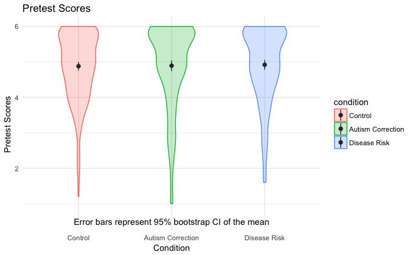

```r
# d_sum %>%
#   ggplot(aes(x=pretest, fill=condition)) +
#   geom_density(alpha=.25) +
#   theme_minimal()
d_sum %>%
  ggplot(aes(x = condition, fill = condition, colour = condition, y = pretest)) +
  geom_violin(width = .5, alpha = .25) +
  stat_summary(fun.data = "mean_cl_boot", fun.args = (list(B = 10000, conf.int = .95)), color = "grey20", shape = 16) +
  theme_minimal() +
  labs(title = "Pretest Scores", y = "Pretest Scores", x = "Condition") +
  annotate("text", label = "Error bars represent 95% bootstrap CI of the mean", x = 2, y = .5)
```

```r
fit_pre <- betareg(rescale_beta(pretest,1,6) ~ condition, data=d_sum)
summary(fit_pre)
```

```
Call:
betareg(formula = rescale_beta(pretest, 1, 6) ~ condition, data = d_sum)

Standardized weighted residuals 2:
    Min      1Q  Median      3Q     Max
-3.7067 -0.6393 -0.3072  0.2879  2.1006

Coefficients (mean model with logit link):
                           Estimate Std. Error z value Pr(>|z|)
(Intercept)                 1.17870    0.07465  15.790   <2e-16 ***
conditionAutism Correction  0.12041    0.10020   1.202    0.229
conditionDisease Risk       0.13541    0.10031   1.350    0.177

Phi coefficients (precision model with identity link):
      Estimate Std. Error z value Pr(>|z|)
(phi)   2.0847     0.1084   19.23   <2e-16 ***
---
Signif. codes:  0 '***' 0.001 '**' 0.01 '*' 0.05 '.' 0.1 ' ' 1

Type of estimator: ML (maximum likelihood)
Log-likelihood:   509 on 4 Df
Pseudo R-squared: 0.002946
Number of iterations: 16 (BFGS) + 1 (Fisher scoring)
```

Participants in the autism correction and disease risk conditions had slightly (tho non-significantly) higher pretest scores than participants in the control condition. Presumably, this should have made it all the more difficult to improve attitudes in those conditions relative to control.

# I. Direct Replication

## Plotting Change Scores

Plotting to replicate Figure 1 from *PNAS* paper.

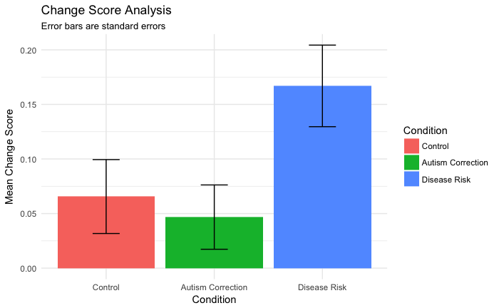

```r
# standard error function
stderr <- function(x) {
          sqrt(var(x[!is.na(x)]) / length(x[!is.na(x)]))
}
d %>%
  filter(Scale=="vaxAttitude") %>%
  group_by(workerId, condition, phase) %>%
  summarize(mean_rating = mean(rating)) %>%
  spread(phase, mean_rating) %>%
  summarize(change_score = posttest-pretest) %>%
  group_by(condition) %>%
  summarize(mean_change = mean(change_score),
            ul = mean(change_score) + stderr(change_score),
            ll = mean(change_score) - stderr(change_score)) %>%
  ggplot(aes(x=condition, fill=condition, y = mean_change, ymin=ll, ymax=ul)) +
  geom_bar(stat="identity") +
  geom_errorbar(width=.25) +
  theme_minimal() +
  labs(title="Change Score Analysis",
       subtitle = "Error bars are standard errors",
       y = "Mean Change Score",
       x = "Condition",
       fill = "Condition")
```

Anaysis of change scores shows significant improvement in disease risk condition. This analysis replicates the original analyses and the primary pre-registered analysis. **We directly replicate the original findings.**

```r
fit_aov <- aov(change ~ condition, data = d_sum)
summary(fit_aov)
```

```
             Df Sum Sq Mean Sq F value Pr(>F)
condition     2   1.94  0.9677   3.619 0.0273 *
Residuals   702 187.71  0.2674
---
Signif. codes:  0 ‘***’ 0.001 ‘**’ 0.01 ‘*’ 0.05 ‘.’ 0.1 ‘ ’ 1
```

```r
t.test(change ~ condition, data = d_sum %>% filter(condition!="Autism Correction"))
```

```
    Welch Two Sample t-test

data:  change by condition
t = -2.0101, df = 464.37, p-value = 0.045
alternative hypothesis: true difference in means is not equal to 0
95 percent confidence interval:
 -0.200495565 -0.002269937
sample estimates:
     mean in group Control mean in group Disease Risk
                0.06557377                 0.16695652
```

```r
dr_control_D <- suppressWarnings(cohen.d(change ~ condition, data = d_sum %>% filter(condition!="Autism Correction"))$estimate)
t.test(change ~ condition, data = d_sum %>% filter(condition!="Control"))
```

```
    Welch Two Sample t-test

data:  change by condition
t = -2.5254, df = 434.86, p-value = 0.01191
alternative hypothesis: true difference in means is not equal to 0
95 percent confidence interval:
 -0.21375281 -0.02665374
sample estimates:
mean in group Autism Correction      mean in group Disease Risk
                     0.04675325                      0.16695652
```

```r
dr_autism_D <- suppressWarnings(cohen.d(change ~ condition, data = d_sum %>% filter(condition!="Control"))$estimate)
```

Comparing the magnitude of the effects, the effect sizes in this replication study are smaller than what was originally observed, with the Disease Risk vs Control D = -0.192 (compared with .41 originally) and Disease Risk vs Autism Correction D = -0.212 (compared with .33 originally).

# II. “Best Model” Replication

ANOVA on change scores is not the optimal approach to analyzing these data. Next, we explore some better ways of modeling the data from this experiment, and evaluate whether these improved statistical models also support the conclusions drawn in the original paper.

The change score analysis has a few issues:

1. Fails to control for or reveal pretest differences between conditions
2. Change scores influenced by both pre-test and posttest measurement error (likely contaminated by regression to the mean)
3. Fails to respect boundaries of original scale (e.g., for Ps near ceiling, negative change scores are largely uninformative)
4. Assumes normal distribution (change scores somewhat non-normal)

Other approaches can avoid some or all of these issues.

## Posttest scores by condition, controlling for pretest

### Linear regression model

Using a linear regression predicting posttest from condition and pretest begins to mitigate the first two issues: it helps to control for pretest differences among conditions (though these can still complicate inference) and allows for modeling error in predicting posttest scores from pretest scores.

```r
fit_lm <- lm(posttest ~ scale(pretest) + condition,
           data=d_sum)
summary(fit_lm)
```

```
Call:
lm(formula = posttest ~ scale(pretest) + condition, data = d_sum)

Residuals:
     Min       1Q   Median       3Q      Max
-2.39433 -0.22196  0.01935  0.21251  2.74165

Coefficients:
                           Estimate Std. Error t value Pr(>|t|)
(Intercept)                 4.95897    0.03097 160.098   <2e-16 ***
scale(pretest)              0.87974    0.01824  48.240   <2e-16 ***
conditionAutism Correction -0.01642    0.04442  -0.370   0.7118
conditionDisease Risk       0.10835    0.04447   2.437   0.0151 *
---
Signif. codes:  0 ‘***’ 0.001 ‘**’ 0.01 ‘*’ 0.05 ‘.’ 0.1 ‘ ’ 1

Residual standard error: 0.4838 on 701 degrees of freedom
Multiple R-squared:  0.7696,    Adjusted R-squared:  0.7686
F-statistic: 780.3 on 3 and 701 DF,  p-value: < 2.2e-16
```

However, this analyses fails to account for the boundedness of the scale nor the non-normal distribution of responses.

### Beta Regression

Beta regression is a more appropriate approach to analyzing bounded, skewed, and heteroscedastic data–three properties of the vaccine attitudes scale responses. For more info, see [this paper](https://www.ncbi.nlm.nih.gov/pubmed/16594767): Smithson M, Verkuilen J (2006) A better lemon squeezer? Maximum-likelihood regression with beta-distributed dependent variables. *Psychol Methods.* 11 (1): 54-71.

The use of Beta regression addresses all four of the major concerns in the change score analyses.

```r
fit_beta <- betareg(rescale_beta(posttest,1,6) ~ scale(pretest) * condition,
           data=d_sum)
summary(fit_beta)
```

```
Call:
betareg(formula = rescale_beta(posttest, 1, 6) ~ scale(pretest) * condition, data = d_sum)

Standardized weighted residuals 2:
    Min      1Q  Median      3Q     Max
-3.2503 -0.6473 -0.2525  0.8458  4.8935

Coefficients (mean model with logit link):
                                           Estimate Std. Error z value Pr(>|z|)
(Intercept)                                1.638577   0.056263  29.123  < 2e-16 ***
scale(pretest)                             1.106032   0.059039  18.734  < 2e-16 ***
conditionAutism Correction                 0.045072   0.077395   0.582  0.56032
conditionDisease Risk                      0.216683   0.077760   2.787  0.00533 **
scale(pretest):conditionAutism Correction  0.095584   0.075897   1.259  0.20789
scale(pretest):conditionDisease Risk      -0.006078   0.078466  -0.077  0.93826

Phi coefficients (precision model with identity link):
      Estimate Std. Error z value Pr(>|z|)
(phi)   7.7871     0.4396   17.72   <2e-16 ***
---
Signif. codes:  0 '***' 0.001 '**' 0.01 '*' 0.05 '.' 0.1 ' ' 1

Type of estimator: ML (maximum likelihood)
Log-likelihood:   991 on 7 Df
Pseudo R-squared: 0.5162
Number of iterations: 15 (BFGS) + 2 (Fisher scoring)
```

### Bayesian beta regression

We also conduct beta regression using bayesian estimation in BRMS.

```r
fit_brm_beta <- cbrm(
  rescale_beta(posttest, 1, 6) ~ scale(pretest) + condition,
  data = d_sum,
  family = Beta(),
  sample_prior = TRUE,
  control = list(adapt_delta = .99),
  # cores = parallel::detectCores(),
  iter = 3000,
  cached_file = "fit_brm_beta.rds"
)
```

This allows us to plot condition effects estimated from the model while marignalizing over pretest scores, along with 50% credible intervals.

```r
summary(fit_brm_beta)
```

```
There were 54 divergent transitions after warmup. Increasing adapt_delta above 0.99 may help.
See http://mc-stan.org/misc/warnings.html#divergent-transitions-after-warmup
```

```
 Family: beta
  Links: mu = logit; phi = identity
Formula: rescale_beta(posttest, 1, 6) ~ scale(pretest) + condition
   Data: data (Number of observations: 705)
Samples: 4 chains, each with iter = 3000; warmup = 1500; thin = 1;
         total post-warmup samples = 6000
    ICs: LOO = NA; WAIC = NA; R2 = NA

Population-Level Effects:
                          Estimate Est.Error l-95% CI u-95% CI Eff.Sample Rhat
Intercept                     1.64      0.06     1.53     1.76       2357 1.00
scalepretest                  1.14      0.03     1.08     1.21       2838 1.00
conditionAutismCorrection     0.03      0.08    -0.12     0.18       2900 1.00
conditionDiseaseRisk          0.22      0.08     0.07     0.36       2631 1.00

Family Specific Parameters:
    Estimate Est.Error l-95% CI u-95% CI Eff.Sample Rhat
phi     7.75      0.43     6.93     8.63       2591 1.00

Samples were drawn using sampling(NUTS). For each parameter, Eff.Sample
is a crude measure of effective sample size, and Rhat is the potential
scale reduction factor on split chains (at convergence, Rhat = 1).
```

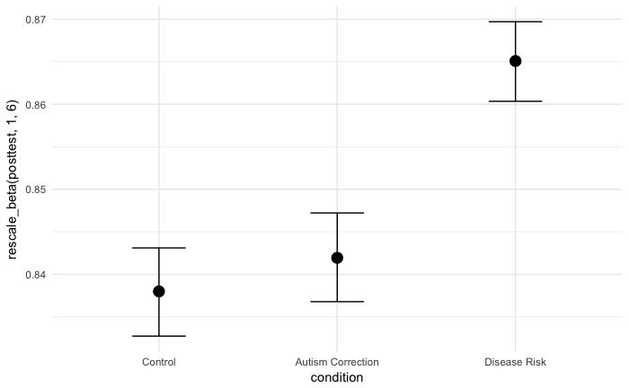

```r
gg_marginal_effects(fit_brm_beta, "condition") %>% plot()
```

### Hierarchical ordinal regression

A final concern in all of the above analyses, on change scores or on posttest scores, is the use of “scores”. That is, the averaging of several ordinal likert scale ratings into a continuous scale variable. Using hierarchical ordinal regression, we can avoid this averaging, and directly model the observed data. This accounts for the ordinal nature of the underlying response variable, as well as possible differences among scale items that are lost to averaging.

```r
fit_brm_ord <- cbrm(
  posttest ~ pretest + condition + (1 | workerId) + (1 | item),
  data = d %>% filter(Scale=="vaxAttitude") %>% spread(phase, rating),
  family = cumulative(),
  cached_file = "fit_brm_ord.rds",
  sample_prior = TRUE,
  control = list(adapt_delta = .85),
  cores = parallel::detectCores(),
  iter = 2000
)
```

```r
summary(fit_brm_ord)
```

```
There were 26 divergent transitions after warmup. Increasing adapt_delta above 0.85 may help.
See http://mc-stan.org/misc/warnings.html#divergent-transitions-after-warmup
```

```
 Family: cumulative
  Links: mu = logit; disc = identity
Formula: posttest ~ pretest + condition + (1 | workerId) + (1 | item)
   Data: data (Number of observations: 3525)
Samples: 4 chains, each with iter = 2000; warmup = 1000; thin = 1;
         total post-warmup samples = 4000
    ICs: LOO = NA; WAIC = NA; R2 = NA

Group-Level Effects:
~item (Number of levels: 5)
              Estimate Est.Error l-95% CI u-95% CI Eff.Sample Rhat
sd(Intercept)     0.66      0.43     0.26     1.95        312 1.02

~workerId (Number of levels: 704)
              Estimate Est.Error l-95% CI u-95% CI Eff.Sample Rhat
sd(Intercept)     1.31      0.09     1.13     1.50        834 1.00

Population-Level Effects:
                          Estimate Est.Error l-95% CI u-95% CI Eff.Sample Rhat
Intercept[1]                  0.93      0.39     0.15     1.69       1029 1.00
Intercept[2]                  2.45      0.39     1.71     3.22       1151 1.00
Intercept[3]                  3.62      0.39     2.88     4.38       1328 1.00
Intercept[4]                  5.26      0.39     4.51     6.05       1263 1.00
Intercept[5]                  8.06      0.41     7.29     8.88       1422 1.00
pretest                       1.49      0.05     1.40     1.58       4000 1.00
conditionAutismCorrection     0.23      0.15    -0.07     0.54       2268 1.00
conditionDiseaseRisk          0.54      0.16     0.23     0.85       2456 1.00

Samples were drawn using sampling(NUTS). For each parameter, Eff.Sample
is a crude measure of effective sample size, and Rhat is the potential
scale reduction factor on split chains (at convergence, Rhat = 1).
```

```
Predictions are treated as continuous variables in 'marginal_effects' by default, which is likely invalid for family 'cumulative'. Consider setting 'ordinal' to TRUE.
```

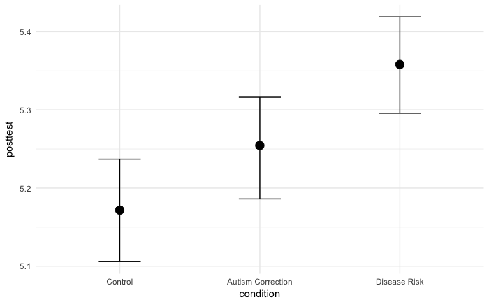

```r
gg_marginal_effects(fit_brm_ord, "condition") %>% plot()
```

## Delayed post-test results

```r
d_post2 <- read_qualtrics_csv("data/Vaccine+PNAS+replication+day3-2018-04-02.csv") %>%
  filter(SC1 == 1) %>%
  select(workerId, contains("Vax3")) %>%
  rename(
    vax_post2_risks = Vax3_Vax1_1,
    vax_post2_herd = Vax3_Vax1_2,
    vax_post2_plan = Vax3_Vax1_3,
    vax_post2_uncommon = Vax3_Vax1_4,
    vax_post2_doctors = Vax3_Vax1_5,
    vax_post2_autism = Vax3_Vax1_6,
    vaxIntent_post2_Iwould = Vax3_Vax1_33,
    vaxIntent_post2_spreadOut = Vax3_Vax1_34,
    vaxIntent_post2_confident = Vax3_Vax1_35,
    vaxIntent_post2_wouldNever = Vax3_Vax1_36
  ) %>%
  mutate(
    vax_post2_risks = 7 - vax_post2_risks,
    vax_post2_uncommon = 7 - vax_post2_uncommon,
    vaxIntent_post2_spreadOut = 7 - vaxIntent_post2_spreadOut,
    vaxIntent_post2_wouldNever = 7 - vaxIntent_post2_wouldNever
  ) %>%
  mutate(
    vaxIntent_post2_risks = vax_post2_risks
  )
d_untidy2 <- d_post2 %>%
  # filter(Vax3_Vax1_check == 5) %>%
  # select(-Vax3_Vax1_check) %>%
  merge(d_untidy, by="workerId") %>%
  select(-Vax3_Vax1_check) %>%
  gather(item, rating, contains("vax"))
d2 <- d_untidy2 %>%
  mutate(
    rating = as.integer(rating),
    phase = ifelse(grepl("_pre_", item),"pretest",
                   ifelse(grepl("_post2_", item), "posttest2", "posttest")),
    Scale = ifelse(grepl("vaxIntent_",item), "vaxIntent", "vaxAttitude"),
    condition = factor(condition,
                       levels=c("bird","autism","cdc_danger"),
                       labels=c("Control","Autism Correction", "Disease Risk"))
    ) %>%
  mutate(condition = relevel(condition, ref="Control")) %>%
  mutate(Scale = ifelse(grepl("autism",item), "autism", Scale)) %>%
  mutate(item=gsub("vax_pre_","", item)) %>%
  mutate(item=gsub("vax_post_","", item)) %>%
  mutate(item=gsub("vaxIntent_pre_","", item)) %>%
  mutate(item=gsub("vaxIntent_post_","", item)) %>%
  mutate(item=gsub("vax_post2_","", item)) %>%
  mutate(item=gsub("vaxIntent_post2_","", item)) %>%
  group_by(workerId, condition, phase, Scale, item) %>% # somehow got a duplicate row
  filter(row_number(rating) == 1) %>% # so remove it
  ungroup()
# and reducing to a "summary" dataset
# d_sum2 <- d2 %>%
#   filter(Scale=="vaxAttitude") %>%
#   group_by(workerId, condition, phase) %>%
#   summarize(mean_rating = mean(rating)) %>%
#   spread(phase, mean_rating) %>%
#   mutate(change = posttest - pretest)
```

### Plotting Raw data

Plotting change scores relative to pretest at posttest and delayed posttest, it looks like disease risk is effective immediately, but not effect compared to control at delay.

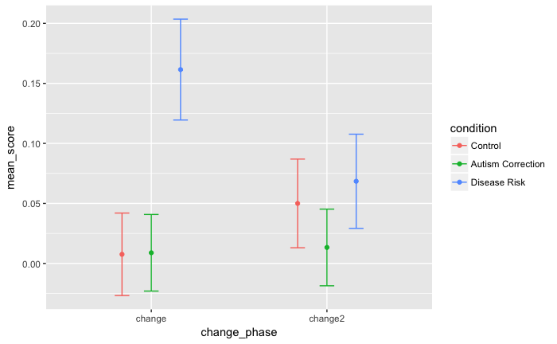

```r
d2 %>%
  filter(Scale == "vaxAttitude") %>%
  group_by(workerId, condition, phase) %>%
  summarize(mean_rating = mean(rating)) %>%
  spread(phase, mean_rating) %>%
  mutate(
    change = posttest - pretest,
    change2 = posttest2 - pretest
  ) %>%
  gather(change_phase, Score, change, change2) %>%
  group_by(condition, change_phase) %>%
  summarize(
    mean_score = mean(Score),
    ul = mean(Score) + stderr(Score),
    ll = mean(Score) - stderr(Score)
  ) %>%
  ggplot(aes(x = change_phase, y = mean_score, color = condition, ymin = ll, ymax = ul)) +
  geom_point(stat = "identity", position = position_dodge(width = .5)) +
  geom_errorbar(position = position_dodge(width = .5), width = .25)
```

However change scores have issues. Let’s just look at the raw overall means across each phase to get a sense of things …

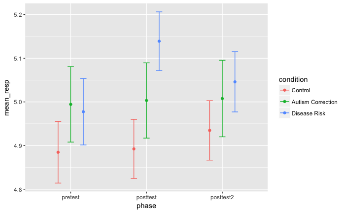

```r
d2 %>%
    filter(Scale=="vaxAttitude") %>%
    group_by(workerId, condition, phase) %>%
    summarize(mean_rating = mean(rating)) %>%
    group_by(condition, phase) %>%
    summarize(mean_resp = mean(mean_rating),
               ul = mean(mean_rating) + stderr(mean_rating),
              ll = mean(mean_rating) - stderr(mean_rating)) %>%
  mutate(phase = factor(phase, levels = c("pretest","posttest","posttest2"))) %>%
  ggplot(aes(x=phase, y = mean_resp, color = condition, ymin = ll, ymax = ul)) +
  geom_point(stat="identity",position=position_dodge(width=.5)) +
  geom_errorbar(position=position_dodge(width=.5), width=.25)
```

### Modeling

First, let’s model things using a beta regression. First, let’s ask if there’s a significant condition difference at delayed postest among the conditions, controlling for original pretest scores.

From this, it looks like there is not. There’s also no magical delayed backfire effect of autism correction.

```r
fit_beta2 <- betareg(rescale_beta(posttest2, 1, 6) ~ scale(pretest) + condition,
                     data = d2 %>%
                       filter(Scale=="vaxAttitude") %>%
                       group_by(workerId, condition, phase) %>%
                       summarize(mean_rating = mean(rating)) %>%
                       spread(phase, mean_rating)
                     )
summary(fit_beta2)
```

```
Call:
betareg(formula = rescale_beta(posttest2, 1, 6) ~ scale(pretest) + condition, data = d2 %>%
    filter(Scale == "vaxAttitude") %>% group_by(workerId, condition, phase) %>%
    summarize(mean_rating = mean(rating)) %>% spread(phase, mean_rating))

Standardized weighted residuals 2:
    Min      1Q  Median      3Q     Max
-4.6930 -0.6527 -0.2897  0.8048  7.7936

Coefficients (mean model with logit link):
                           Estimate Std. Error z value Pr(>|z|)
(Intercept)                 1.69646    0.06386  26.563   <2e-16 ***
scale(pretest)              1.16799    0.03840  30.414   <2e-16 ***
conditionAutism Correction  0.01312    0.08668   0.151    0.880
conditionDisease Risk       0.04308    0.08510   0.506    0.613

Phi coefficients (precision model with identity link):
      Estimate Std. Error z value Pr(>|z|)
(phi)   7.9341     0.5063   15.67   <2e-16 ***
---
Signif. codes:  0 '***' 0.001 '**' 0.01 '*' 0.05 '.' 0.1 ' ' 1

Type of estimator: ML (maximum likelihood)
Log-likelihood: 751.3 on 5 Df
Pseudo R-squared: 0.5098
Number of iterations: 12 (BFGS) + 3 (Fisher scoring)
```

Now let’s try to put everything together into one model. This model will predict both immediate and delayed posttest responses from pretest and condition, along with a “time” variable coding whether they are immediate or delayed responses. I’ll let this interact with condition, since the change scores suggest the effects of time might be different in the different conditions.

```r
d2_sum <- d2 %>%
  filter(Scale == "vaxAttitude") %>%
  group_by(workerId, condition, phase) %>%
  summarize(mean_rating = mean(rating)) %>%
  spread(phase, mean_rating) %>%
  gather(time, response, posttest, posttest2)
# fit_beta2 <- brm(rescale_beta(response,1,6) ~ scale(pretest) + time * condition + (1|workerId), data = d2_sum )
fit_brm_beta2 <- cbrm(
  rescale_beta(response,1,6) ~ scale(pretest) + time * condition + (1|workerId),
  data = d2_sum,
  family = Beta(), # student(), #cumulative(), #bernoulli(), etc
  cached_file = "fit_brm_beta2.rds",
  control = list(adapt_delta = .95),
  sample_prior = TRUE,
  cores = parallel::detectCores(),
  iter = 2000
)
```

```r
summary(fit_brm_beta2)
```

```
There were 210 divergent transitions after warmup. Increasing adapt_delta above 0.95 may help.
See http://mc-stan.org/misc/warnings.html#divergent-transitions-after-warmup
```

```
 Family: beta
  Links: mu = logit; phi = identity
Formula: rescale_beta(response, 1, 6) ~ scale(pretest) + time * condition + (1 | workerId)
   Data: data (Number of observations: 1102)
Samples: 4 chains, each with iter = 2000; warmup = 1000; thin = 1;
         total post-warmup samples = 4000
    ICs: LOO = NA; WAIC = NA; R2 = NA

Group-Level Effects:
~workerId (Number of levels: 551)
              Estimate Est.Error l-95% CI u-95% CI Eff.Sample Rhat
sd(Intercept)     0.67      0.04     0.59     0.74        832 1.00

Population-Level Effects:
                                        Estimate Est.Error l-95% CI u-95% CI Eff.Sample Rhat
Intercept                                   1.74      0.07     1.60     1.87       1977 1.00
scalepretest                                1.30      0.04     1.23     1.37       2032 1.00
timeposttest2                               0.06      0.07    -0.07     0.20       3077 1.00
conditionAutismCorrection                   0.14      0.10    -0.06     0.34       2045 1.00
conditionDiseaseRisk                        0.39      0.10     0.21     0.59       2124 1.00
timeposttest2:conditionAutismCorrection    -0.04      0.10    -0.24     0.16       4000 1.00
timeposttest2:conditionDiseaseRisk         -0.25      0.10    -0.45    -0.07       4000 1.00

Family Specific Parameters:
    Estimate Est.Error l-95% CI u-95% CI Eff.Sample Rhat
phi    15.06      1.05    13.10    17.21        942 1.00

Samples were drawn using sampling(NUTS). For each parameter, Eff.Sample
is a crude measure of effective sample size, and Rhat is the potential
scale reduction factor on split chains (at convergence, Rhat = 1).
```

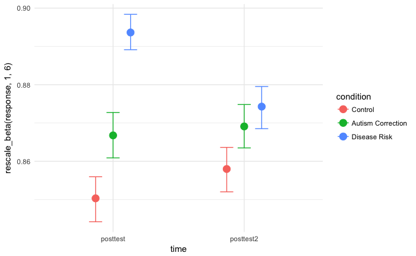

```r
gg_marginal_effects(fit_brm_beta2, "time:condition") %>% plot()
```

Using the marignal effects plot lets us pull out the model predictions without having to worry about interpreting beta regression coefficients. Here I’m using 50% credible intervals. It looks like, at immediate test, disease risk shows a significant improvement over control and autism correction, as previously observed. At delayed test, it’s fallen back down but it looks like it’s still expected to be a bit better than control. I’ll have to test that hypothesis inside the model somehow. Likewise, there’s a hint that autism correction looks better than control in this sample/analysis, which I’ll have to look at more closely.

It’s actually not that crazy. Let’s also rerun the model as a hierarchical ordinal regression …

```r
fit_brm_ord2 <- cbrm(
  response ~ phase * condition + (1 | workerId) + (1|item),
  data = d2 %>%
    filter(Scale == "vaxAttitude") %>%
    group_by(workerId, condition, phase) %>%
    select(item, phase, condition, workerId, rating) %>%
    ungroup() %>%
    spread(phase, rating) %>%
    gather(phase, response, posttest, posttest2) %>%
    mutate(phase = relevel(factor(phase), ref = "posttest")),
  family = cumulative(),
  cached_file = "fit_brm_ord2.rds",
  sample_prior = TRUE,
  control = list(adapt_delta = .85),
  cores = parallel::detectCores(),
  iter = 2000
)
```

[output not shown]

[output cut: 44 more lines]

[output not shown]

[output not shown]

```r
summary(fit_brm_ord2)
```

```
There were 6 divergent transitions after warmup. Increasing adapt_delta above 0.85 may help.
See http://mc-stan.org/misc/warnings.html#divergent-transitions-after-warmup
```

```
 Family: cumulative
  Links: mu = logit; disc = identity
Formula: response ~ phase * condition + (1 | workerId) + (1 | item)
   Data: data (Number of observations: 5510)
Samples: 4 chains, each with iter = 2000; warmup = 1000; thin = 1;
         total post-warmup samples = 4000
    ICs: LOO = NA; WAIC = NA; R2 = NA

Group-Level Effects:
~item (Number of levels: 5)
              Estimate Est.Error l-95% CI u-95% CI Eff.Sample Rhat
sd(Intercept)     1.23      0.69     0.52     3.18        941 1.00

~workerId (Number of levels: 551)
              Estimate Est.Error l-95% CI u-95% CI Eff.Sample Rhat
sd(Intercept)     2.87      0.11     2.65     3.10        792 1.00

Population-Level Effects:
                                         Estimate Est.Error l-95% CI u-95% CI Eff.Sample
Intercept[1]                                -5.70      0.66    -6.87    -4.23        450
Intercept[2]                                -4.46      0.65    -5.64    -3.02        444
Intercept[3]                                -3.49      0.65    -4.69    -2.06        441
Intercept[4]                                -2.03      0.65    -3.22    -0.58        442
Intercept[5]                                 0.74      0.65    -0.43     2.19        436
phaseposttest2                               0.13      0.10    -0.07     0.32       2983
conditionAutismCorrection                    0.67      0.32     0.04     1.29        344
conditionDiseaseRisk                         0.96      0.32     0.34     1.63        292
phaseposttest2:conditionAutismCorrection    -0.16      0.15    -0.45     0.12       4000
phaseposttest2:conditionDiseaseRisk         -0.46      0.14    -0.74    -0.18       4000
                                         Rhat
Intercept[1]                             1.01
Intercept[2]                             1.01
Intercept[3]                             1.01
Intercept[4]                             1.01
Intercept[5]                             1.01
phaseposttest2                           1.00
conditionAutismCorrection                1.01
conditionDiseaseRisk                     1.01
phaseposttest2:conditionAutismCorrection 1.00
phaseposttest2:conditionDiseaseRisk      1.00

Samples were drawn using sampling(NUTS). For each parameter, Eff.Sample
is a crude measure of effective sample size, and Rhat is the potential
scale reduction factor on split chains (at convergence, Rhat = 1).
```

```r
hypothesis(fit_brm_ord2, "conditionDiseaseRisk + phaseposttest2:conditionDiseaseRisk > 0")
```

```
Hypothesis Tests for class b:
                         Estimate Est.Error l-95% CI u-95% CI Evid.Ratio Star
(conditionDisease... > 0     0.49      0.32    -0.01      Inf      17.02
---
'*': The expected value under the hypothesis lies outside the 95% CI.
```

```r
# maybe look directly at posterior distributions? chance to try tidybayes?
```

### Predicting response

Now that we have multiple posttest periods, it might be preferrable to use a model that predicts responses across all phases. This feels a bit less piecemeal than the past models, although it might be less powerful.

Model:

```
response ~ phase * condition + (1|participant)
```

```r
fit_brm_beta2_resp <- cbrm(
  rescale_beta(response, 1, 6) ~ phase * condition + (1 | workerId),
  data = d2 %>%
    filter(Scale == "vaxAttitude") %>%
    mutate(phase = relevel(factor(phase), ref = "pretest")) %>%
    group_by(workerId, condition, phase) %>%
    summarize(response = mean(rating)),
  family = Beta(),
  seed = 12345,
  cached_file = "fit_brm_beta2_resp.rds",
  sample_prior = TRUE,
  control = list(adapt_delta = .95),
  cores = parallel::detectCores(),
  iter = 2000
)
```

```r
summary(fit_brm_beta2_resp)
```

```
There were 118 divergent transitions after warmup. Increasing adapt_delta above 0.95 may help.
See http://mc-stan.org/misc/warnings.html#divergent-transitions-after-warmup
```

```
 Family: beta
  Links: mu = logit; phi = identity
Formula: rescale_beta(response, 1, 6) ~ phase * condition + (1 | workerId)
   Data: data (Number of observations: 1653)
Samples: 4 chains, each with iter = 2000; warmup = 1000; thin = 1;
         total post-warmup samples = 4000
    ICs: LOO = NA; WAIC = NA; R2 = NA

Group-Level Effects:
~workerId (Number of levels: 551)
              Estimate Est.Error l-95% CI u-95% CI Eff.Sample Rhat
sd(Intercept)     1.59      0.06     1.48     1.70        345 1.01

Population-Level Effects:
                                         Estimate Est.Error l-95% CI u-95% CI Eff.Sample
Intercept                                    1.72      0.12     1.47     1.97        212
phaseposttest                               -0.01      0.06    -0.13     0.11       1333
phaseposttest2                               0.06      0.07    -0.07     0.18       1228
conditionAutismCorrection                    0.29      0.17    -0.04     0.63        259
conditionDiseaseRisk                         0.26      0.18    -0.09     0.61        247
phaseposttest:conditionAutismCorrection      0.01      0.10    -0.17     0.20       1624
phaseposttest2:conditionAutismCorrection    -0.05      0.09    -0.23     0.14       1680
phaseposttest:conditionDiseaseRisk           0.28      0.09     0.10     0.46       1676
phaseposttest2:conditionDiseaseRisk          0.04      0.09    -0.15     0.22       1233
                                         Rhat
Intercept                                1.03
phaseposttest                            1.00
phaseposttest2                           1.00
conditionAutismCorrection                1.01
conditionDiseaseRisk                     1.02
phaseposttest:conditionAutismCorrection  1.00
phaseposttest2:conditionAutismCorrection 1.00
phaseposttest:conditionDiseaseRisk       1.00
phaseposttest2:conditionDiseaseRisk      1.00

Family Specific Parameters:
    Estimate Est.Error l-95% CI u-95% CI Eff.Sample Rhat
phi    16.84      0.80    15.32    18.39       2040 1.00

Samples were drawn using sampling(NUTS). For each parameter, Eff.Sample
is a crude measure of effective sample size, and Rhat is the potential
scale reduction factor on split chains (at convergence, Rhat = 1).
```

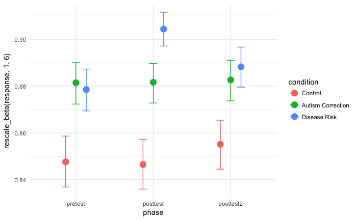

```r
gg_marginal_effects(fit_brm_beta2_resp, "phase:condition") %>% plot()
```

That seems like a pretty clear summary of the results, in a model that captures the pretest differences explicitly.

Just to be safe, we can do it as a hierarchical ordinal model as well.

```r
# fit_brm_ord2b <- brm(
#   rating ~ phase * condition + (1 | workerId) + (1 | item),
#   data = d2 %>%
#     filter(Scale == "vaxAttitude") %>%
#     mutate(phase = factor(phase, levels = c("pretest","posttest","posttest2"))) %>%
#     select(workerId, item, phase, condition, rating),
#   family = cumulative(),
#   sample_prior = TRUE,
#   control = list(adapt_delta = .85),
#   cores = parallel::detectCores(),
#   iter = 2000
# )
```

```r
# summary(fit_brm_ord2b)
# gg_marginal_effects(fit_brm_ord2b, "phase:condition") %>% plot()
```

So at the end of all that, it’s not really all that clear what happened after a delay! The conclusions we’d draw seem to depend heavily on the analytic choices we make.

# III. “Vaccine intent” scale results

Here’s a plot of the change scores for the vaccine intent scale across conditions. The differences here are somewhat smaller than for “vaccine attitudes”, but they appear significant.

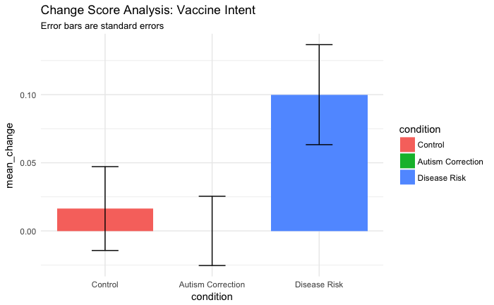

```r
d %>%
  filter(Scale=="vaxIntent") %>%
  group_by(workerId, condition, phase) %>%
  summarize(mean_rating = mean(rating)) %>%
  spread(phase, mean_rating) %>%
  summarize(change_score = posttest-pretest) %>%
  group_by(condition) %>%
  summarize(mean_change = mean(change_score),
            ul = mean(change_score) + stderr(change_score),
            ll = mean(change_score) - stderr(change_score)) %>%
  ggplot(aes(x=condition, fill=condition, y = mean_change, ymin=ll, ymax=ul)) +
  geom_bar(stat="identity") +
  geom_errorbar(width=.25) +
  theme_minimal() +
  labs(title="Change Score Analysis: Vaccine Intent",
       subtitle = "Error bars are standard errors")
```

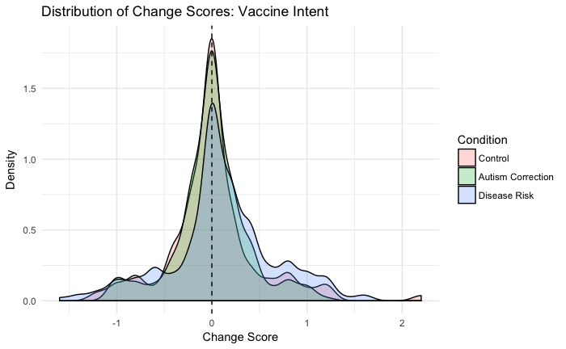

```r
d %>%
  filter(Scale=="vaxIntent") %>%
  group_by(workerId, condition, phase) %>%
  summarize(mean_rating = mean(rating)) %>%
  spread(phase, mean_rating) %>%
  summarize(change_score = posttest-pretest) %>%
  ggplot(aes(x = change_score, fill = condition)) +
  # geom_histogram(binwidth = 0.25, alpha = 0.25, position = "identity") +
  geom_density(alpha = 0.25, position = "identity") +
  geom_vline(xintercept = 0, lty = 2) +
  theme_minimal() +
  labs(title = "Distribution of Change Scores: Vaccine Intent",
       x = "Change Score", y = "Density", fill = "Condition")
```

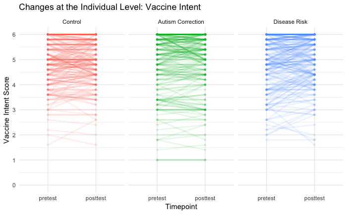

```r
d %>%
  filter(Scale=="vaxIntent") %>%
  mutate(phase = factor(phase, levels = c("pretest", "posttest"))) %>%
  group_by(workerId, condition, phase) %>%
  summarize(mean_rating = mean(rating)) %>%
  ggplot(aes(x = phase, color = condition, y = mean_rating)) +
  facet_grid(~ condition) +
  geom_line(aes(group = workerId), alpha = 0.1, size = 1) +
  geom_point(alpha = 0.1, size = 1) +
  scale_y_continuous(limits = c(0, 6), breaks = 0:6) +
  theme_minimal() +
  theme(legend.position = "none") +
  labs(title = "Changes at the Individual Level: Vaccine Intent",
       x = "Timepoint", y = "Vaccine Intent Score")
```

## Linear regression

Under the linear regression model, the contrast between control and disease risk conditions is just barely non-significant at the $\alpha = .05$ level.

```r
d_sum_intent <- d %>%
  filter(Scale == "vaxIntent") %>%
  group_by(workerId, condition, phase) %>%
  summarize(mean_rating = mean(rating)) %>%
  spread(phase, mean_rating)
fit_lm_intent <- lm(posttest ~ scale(pretest) + condition, data = d_sum_intent)
summary(fit_lm_intent)
```

```
Call:
lm(formula = posttest ~ scale(pretest) + condition, data = d_sum_intent)

Residuals:
     Min       1Q   Median       3Q      Max
-1.92585 -0.21691  0.03868  0.18256  2.00860

Coefficients:
                           Estimate Std. Error t value Pr(>|t|)
(Intercept)                 4.95386    0.02944 168.249   <2e-16 ***
scale(pretest)              0.91328    0.01733  52.686   <2e-16 ***
conditionAutism Correction -0.01827    0.04222  -0.433   0.6654
conditionDisease Risk       0.08237    0.04227   1.949   0.0517 .
---
Signif. codes:  0 ‘***’ 0.001 ‘**’ 0.01 ‘*’ 0.05 ‘.’ 0.1 ‘ ’ 1

Residual standard error: 0.4599 on 701 degrees of freedom
Multiple R-squared:  0.7987,    Adjusted R-squared:  0.7979
F-statistic: 927.4 on 3 and 701 DF,  p-value: < 2.2e-16
```

## Beta regression

However, by beta regression, the main contrast is significant.

```r
d_sum_intent <- d %>%
  filter(Scale == "vaxIntent") %>%
  group_by(workerId, condition, phase) %>%
  summarize(mean_rating = mean(rating)) %>%
  spread(phase, mean_rating)
fit_beta_intent <- betareg(
  rescale_beta(posttest, 1, 6) ~ scale(pretest) * condition,
  data = d_sum_intent
)
summary(fit_beta_intent)
```

```
Call:
betareg(formula = rescale_beta(posttest, 1, 6) ~ scale(pretest) * condition, data = d_sum_intent)

Standardized weighted residuals 2:
    Min      1Q  Median      3Q     Max
-2.6943 -0.6615 -0.2401  0.9362  5.4614

Coefficients (mean model with logit link):
                                          Estimate Std. Error z value Pr(>|z|)
(Intercept)                                1.65084    0.05445  30.319  < 2e-16 ***
scale(pretest)                             1.19109    0.05872  20.283  < 2e-16 ***
conditionAutism Correction                 0.09155    0.07552   1.212  0.22539
conditionDisease Risk                      0.21931    0.07575   2.895  0.00379 **
scale(pretest):conditionAutism Correction  0.08948    0.07465   1.199  0.23066
scale(pretest):conditionDisease Risk      -0.02225    0.07667  -0.290  0.77163

Phi coefficients (precision model with identity link):
      Estimate Std. Error z value Pr(>|z|)
(phi)   8.7212     0.4936   17.67   <2e-16 ***
---
Signif. codes:  0 '***' 0.001 '**' 0.01 '*' 0.05 '.' 0.1 ' ' 1

Type of estimator: ML (maximum likelihood)
Log-likelihood:  1055 on 7 Df
Pseudo R-squared: 0.5563
Number of iterations: 15 (BFGS) + 4 (Fisher scoring)
```

## Ordinal HLM

Again, this is likely the most appropriate analysis for these data.

```r
fit_brm_ord_intent <- cbrm(
  posttest ~ pretest + condition + (1 | workerId) + (1 | item),
  data = d %>% filter(Scale == "vaxIntent") %>% spread(phase, rating),
  family = cumulative(), # student(), #cumulative(), #bernoulli(), etc
  sample_prior = TRUE,
  cached_file = "fit_brm_ord_intent.rds",
  control = list(adapt_delta = .95),
  cores = parallel::detectCores(),
  iter = 2000
)
```

[output not shown]

[output cut: 44 more lines]

[output not shown]

[output not shown]

```r
summary(fit_brm_ord_intent)
```

```
There were 4 divergent transitions after warmup. Increasing adapt_delta above 0.95 may help.
See http://mc-stan.org/misc/warnings.html#divergent-transitions-after-warmup
```

```
 Family: cumulative
  Links: mu = logit; disc = identity
Formula: posttest ~ pretest + condition + (1 | workerId) + (1 | item)
   Data: data (Number of observations: 3525)
Samples: 4 chains, each with iter = 2000; warmup = 1000; thin = 1;
         total post-warmup samples = 4000
    ICs: LOO = NA; WAIC = NA; R2 = NA

Group-Level Effects:
~item (Number of levels: 5)
              Estimate Est.Error l-95% CI u-95% CI Eff.Sample Rhat
sd(Intercept)     0.80      0.47     0.32     2.07       1152 1.00

~workerId (Number of levels: 704)
              Estimate Est.Error l-95% CI u-95% CI Eff.Sample Rhat
sd(Intercept)     1.00      0.09     0.83     1.18        562 1.01

Population-Level Effects:
                          Estimate Est.Error l-95% CI u-95% CI Eff.Sample Rhat
Intercept[1]                  1.86      0.47     0.93     2.81       1285 1.00
Intercept[2]                  3.53      0.47     2.59     4.50       1338 1.00
Intercept[3]                  4.83      0.47     3.89     5.79       1334 1.00
Intercept[4]                  6.43      0.48     5.47     7.42       1347 1.00
Intercept[5]                  8.97      0.50     8.01     9.98       1520 1.00
pretest                       1.69      0.05     1.60     1.79       2996 1.00
conditionAutismCorrection     0.20      0.13    -0.06     0.45       2191 1.00
conditionDiseaseRisk          0.44      0.13     0.18     0.71       2202 1.00

Samples were drawn using sampling(NUTS). For each parameter, Eff.Sample
is a crude measure of effective sample size, and Rhat is the potential
scale reduction factor on split chains (at convergence, Rhat = 1).
```

```r
# gg_marginal_effects(fit_brm_ord_intent, "condition") %>% plot()
```

## Delayed post-test and vaccine intentions

### Plotting Raw data

Plotting change scores relative to pretest at posttest and delayed posttest, it looks like disease risk is effective immediately, but not effect compared to control at delay. There’s actually even some sign of backfire for autism correction at delay, unclear what that means.

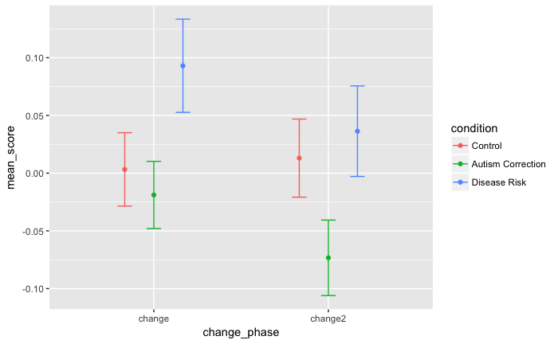

```r
d2 %>%
  filter(Scale == "vaxIntent") %>%
  group_by(workerId, condition, phase) %>%
  summarize(mean_rating = mean(rating)) %>%
  spread(phase, mean_rating) %>%
  mutate(
    change = posttest - pretest,
    change2 = posttest2 - pretest
  ) %>%
  gather(change_phase, Score, change, change2) %>%
  group_by(condition, change_phase) %>%
  summarize(
    mean_score = mean(Score),
    ul = mean(Score) + stderr(Score),
    ll = mean(Score) - stderr(Score)
  ) %>%
  ggplot(aes(x = change_phase, y = mean_score, color = condition, ymin = ll, ymax = ul)) +
  geom_point(stat = "identity", position = position_dodge(width = .5)) +
  geom_errorbar(position = position_dodge(width = .5), width = .25)
```

However change scores have issues. Let’s just look at the raw overall means across each phase to get a sense of things …

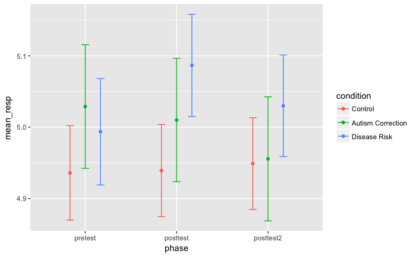

```r
d2 %>%
    filter(Scale=="vaxIntent") %>%
    group_by(workerId, condition, phase) %>%
    summarize(mean_rating = mean(rating)) %>%
    group_by(condition, phase) %>%
    summarize(mean_resp = mean(mean_rating),
               ul = mean(mean_rating) + stderr(mean_rating),
              ll = mean(mean_rating) - stderr(mean_rating)) %>%
  mutate(phase = factor(phase, levels = c("pretest","posttest","posttest2"))) %>%
  ggplot(aes(x=phase, y = mean_resp, color = condition, ymin = ll, ymax = ul)) +
  geom_point(stat="identity",position=position_dodge(width=.5)) +
  geom_errorbar(position=position_dodge(width=.5), width=.25)
```

Now it’s pretty clear that the “backfire” of the autism correction looks like an artifact of the change scores, as it’s higher than control in each time point.

### Modeling

First, let’s model things using a beta regression. First, let’s ask if there’s a significant condition difference at delayed postest among the conditions, controlling for original pretest scores.

From this, it looks like it’s close but not quite for disease risk.

```r
fit_beta_intent <- betareg(rescale_beta(posttest2, 1, 6) ~ scale(pretest) + condition,
                     data = d2 %>%
                       filter(Scale=="vaxIntent") %>%
                       group_by(workerId, condition, phase) %>%
                       summarize(mean_rating = mean(rating)) %>%
                       spread(phase, mean_rating)
                     )
summary(fit_beta_intent)
```

```
Call:
betareg(formula = rescale_beta(posttest2, 1, 6) ~ scale(pretest) + condition, data = d2 %>%
    filter(Scale == "vaxIntent") %>% group_by(workerId, condition, phase) %>% summarize(mean_rating = mean(rating)) %>%
    spread(phase, mean_rating))

Standardized weighted residuals 2:
    Min      1Q  Median      3Q     Max
-1.7945 -0.6815 -0.2611  0.7450  4.8647

Coefficients (mean model with logit link):
                           Estimate Std. Error z value Pr(>|z|)
(Intercept)                 1.66369    0.06114  27.209   <2e-16 ***
scale(pretest)              1.17385    0.03689  31.822   <2e-16 ***
conditionAutism Correction  0.06713    0.08397   0.799   0.4241
conditionDisease Risk       0.14771    0.08237   1.793   0.0729 .

Phi coefficients (precision model with identity link):
      Estimate Std. Error z value Pr(>|z|)
(phi)   8.7660     0.5575   15.72   <2e-16 ***
---
Signif. codes:  0 '***' 0.001 '**' 0.01 '*' 0.05 '.' 0.1 ' ' 1

Type of estimator: ML (maximum likelihood)
Log-likelihood: 769.5 on 5 Df
Pseudo R-squared: 0.5103
Number of iterations: 14 (BFGS) + 4 (Fisher scoring)
```

```r
# fit_brm_beta_intent_delay <- cbrm(
#   rescale_beta(posttest2, 1, 6) ~ scale(pretest) + condition,
#   data = d2 %>%
#     filter(Scale == "vaxIntent") %>%
#     group_by(workerId, condition, phase) %>%
#     summarize(mean_rating = mean(rating)) %>%
#     spread(phase, mean_rating),
#   family = Beta(),
#   prior = c(set_prior("normal(0,.5)", coef = "conditionDiseaseRisk"),
#             set_prior("normal(0,.5)", coef = "conditionAutismCorrection")),
#   cached_file = "fit_brm_beta_intent_delay.rds",
#   sample_prior = TRUE,
#   control = list(adapt_delta = .99),
#   cores = parallel::detectCores(),
#   iter = 3000,
#   warmup = 2000
# )
```

Now let’s try to put everything together into one model. This model will predict both immediate and delayed posttest responses from pretest and condition, along with a “time” variable coding whether they are immediate or delayed responses. I’ll let this interact with condition, since the change scores suggest the effects of time might be different in the different conditions.

```r
d2_sum <- d2 %>%
  filter(Scale == "vaxIntent") %>%
  group_by(workerId, condition, phase) %>%
  summarize(mean_rating = mean(rating)) %>%
  spread(phase, mean_rating) %>%
  gather(time, response, posttest, posttest2)
fit_brm_beta_intent <- cbrm(
  rescale_beta(response,1,6) ~ scale(pretest) + time * condition + (1|workerId),
  data = d2_sum,
  family = Beta(), # student(), #cumulative(), #bernoulli(), etc
  prior = c(prior(normal(0,1), class = b),
            prior(normal(0,5), coef=scalepretest)),
  cached_file = "fit_brm_beta_intent.rds",
  sample_prior = TRUE,
  control = list(adapt_delta = .95),
  cores = parallel::detectCores(),
  iter = 2000
)
```

[output not shown]

[output cut: 44 more lines]

[output not shown]

[output not shown]

```r
summary(fit_brm_beta_intent)
```

```
There were 262 divergent transitions after warmup. Increasing adapt_delta above 0.95 may help.
See http://mc-stan.org/misc/warnings.html#divergent-transitions-after-warmup
```

```
 Family: beta
  Links: mu = logit; phi = identity
Formula: rescale_beta(response, 1, 6) ~ scale(pretest) + time * condition + (1 | workerId)
   Data: data (Number of observations: 1102)
Samples: 4 chains, each with iter = 2000; warmup = 1000; thin = 1;
         total post-warmup samples = 4000
    ICs: LOO = NA; WAIC = NA; R2 = NA

Group-Level Effects:
~workerId (Number of levels: 551)
              Estimate Est.Error l-95% CI u-95% CI Eff.Sample Rhat
sd(Intercept)     0.64      0.04     0.56     0.72        755 1.00

Population-Level Effects:
                                        Estimate Est.Error l-95% CI u-95% CI Eff.Sample Rhat
Intercept                                   1.76      0.07     1.63     1.90       1462 1.00
scalepretest                                1.31      0.04     1.24     1.37       1449 1.00
timeposttest2                               0.01      0.07    -0.12     0.14       2231 1.00
conditionAutismCorrection                   0.20      0.10     0.00     0.39       1711 1.00
conditionDiseaseRisk                        0.31      0.10     0.11     0.50       1400 1.01
timeposttest2:conditionAutismCorrection    -0.08      0.10    -0.28     0.12       2556 1.00
timeposttest2:conditionDiseaseRisk         -0.13      0.10    -0.32     0.06       2582 1.00

Family Specific Parameters:
    Estimate Est.Error l-95% CI u-95% CI Eff.Sample Rhat
phi    15.22      1.06    13.22    17.41        967 1.00

Samples were drawn using sampling(NUTS). For each parameter, Eff.Sample
is a crude measure of effective sample size, and Rhat is the potential
scale reduction factor on split chains (at convergence, Rhat = 1).
```

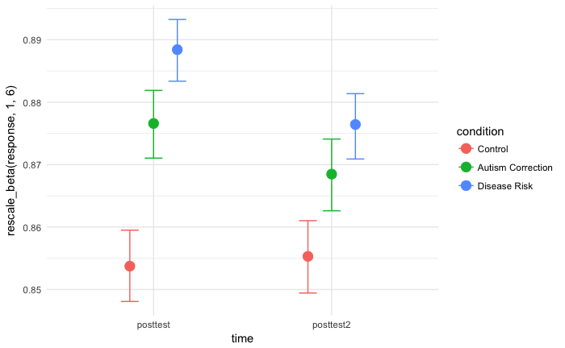

```r
gg_marginal_effects(fit_brm_beta_intent, "time:condition") %>% plot()
```

```r
# test P that diseaseRisk differs from control at T2, after controlling for pretest scores
fit_brm_beta_intent %>%
  spread_samples(b_timeposttest2,
                 b_conditionDiseaseRisk,
                 `b_timeposttest2:conditionDiseaseRisk`) %>%
  mutate(time2_effect = b_conditionDiseaseRisk + `b_timeposttest2:conditionDiseaseRisk`) %>%
  gather(term, estimate, b_timeposttest2:time2_effect) %>%
  group_by(term) %>%
  summarize(p_above_zero = sum(ifelse(estimate > 0, 1, 0)) / n()) %>%
  filter(term == "time2_effect")
```

| term | p_above_zero |
| --- | --- |
| time2_effect | 0.9705 |

Using the marignal effects plot lets us pull out the model predictions without having to worry about interpreting beta regression coefficients. Here I’m using 50% credible intervals. It looks like, at immediate test, disease risk shows a significant improvement over control and autism correction, as previously observed. At delayed test, it’s fallen back down but it looks like it’s still expected to be better than control. I’ll have to test that hypothesis inside the model somehow. Likewise, there’s a hint that autism correction looks better than control in this sample/analysis, which I’ll have to look at more closely.

```r
# fit_brm_ord_intent <- brm(
#   response ~ pretest + time * condition + (1 | workerId) + (1|item),
#   data = d2 %>%
#     filter(Scale == "vaxIntent") %>%
#     group_by(workerId, condition, phase) %>%
#     select(item, phase, condition, workerId, rating) %>%
#     spread(phase, rating) %>%
#     gather(time, response, posttest, posttest2),
#   family = cumulative(),
#   cached_file = "fit_brm_ord_intent.rds",
#   sample_prior = TRUE,
#   control = list(adapt_delta = .85),
#   cores = parallel::detectCores(),
#   iter = 2000
# )
```

```r
# summary(fit_brm_ord_intent)
# gg_marginal_effects(fit_brm_ord_intent, "time:condition") %>% plot()
```

### Predicting response

Now that we have multiple posttest periods, it might be preferrable to use a model that predicts responses across all phases. This feels a bit less piecemeal than the past models, although it might be less powerful.

Model:

```
response ~ phase * condition + (1|participant)
```

```r
# fit_brm_beta_resp_intent <- brm(
#   rescale_beta(response, 1, 6) ~ phase * condition + (1 | workerId),
#   data = d2 %>%
#     filter(Scale == "vaxIntent") %>%
#     mutate(phase = relevel(factor(phase), ref = "pretest")) %>%
#     group_by(workerId, condition, phase) %>%
#     summarize(response = mean(rating)),
#   family = Beta(),
#   cached_file = "fit_brm_beta_resp_intent.rds",
#   sample_prior = TRUE,
#   control = list(adapt_delta = .95),
#   cores = parallel::detectCores(),
#   iter = 2000
# )
```

```r
# summary(fit_brm_beta_resp_intent)
# gg_marginal_effects(fit_brm_beta_resp_intent, "phase:condition") %>% plot()
```

Just to be safe, we can do it as a hierarchical ordinal model as well.

```r
# fit_brm_ord2_resp_intent <- brm(
#   rating ~ phase * condition + (1 | workerId) + (1 | item),
#   data = d2 %>%
#     filter(Scale == "vaxIntent") %>%
#     group_by(workerId, condition, phase) %>%
#     select(item, phase, condition, workerId, rating) %>%
#     ungroup() %>%
#     mutate(phase = relevel(factor(phase), ref = "pretest")),
#   family = cumulative(),
#   sample_prior = TRUE,
#   control = list(adapt_delta = .85),
#   cores = parallel::detectCores(),
#   iter = 2000
# )
```

```r
# summary(fit_brm_ord2_resp_intent)
# gg_marginal_effects(fit_brm_ord2_resp_intent, "phase:condition") %>% plot()
```

So at the end of all that, it’s not really all that clear what happened after a delay! The conclusions we’d draw seem to depend heavily on the analytic choices we make.

# IV. Additional analyses

To be explored:

- Examine demographics of participants
- Examine predictions of vaccine behavior for both scales (started)
- Estimate predicted reduction in vaccine refusals based on attitude change and behavior

## Vaccine behavior: delay and refusal

How many parents have delayed, refused, or sought exemptions from vaccines? *Sought exemptio items should now be fixed, 4/9/18, 10:43 AM)*.

```r
d %>%
  group_by(parent, workerId) %>%
  summarize(
    flu = mean(flu, na.rm=TRUE),
    flu_next = mean(flu2, na.rm=TRUE),
    flu_child = mean(flu3, na.rm=TRUE),
    flu_child_next = mean(flu4, na.rm=TRUE),
    delay = mean(delay, na.rm=TRUE),
    refuse = mean(refuse, na.rm=TRUE)) %>%
  summarize(
    flu = mean(flu, na.rm=TRUE),
    flu_next = mean(flu_next, na.rm=TRUE),
    flu_child = mean(flu_child, na.rm=TRUE),
    flu_child_next = mean(flu_child_next, na.rm=TRUE),
    delay = mean(delay, na.rm=TRUE),
    refuse = mean(refuse, na.rm=TRUE))
```

| parent | flu | flu_next | flu_child | flu_child_next | delay | refuse |
| --- | --- | --- | --- | --- | --- | --- |
| 0 | 0.2969543 | 0.4543147 | NaN | NaN | NaN | NaN |
| 1 | 0.4387097 | 0.5451613 | 0.5387097 | 0.6193548 | 0.1935484 | 0.1193548 |

How do pretest vaccine attitudes predict refusals?

```r
d_sum_behavior <- d %>%
  mutate(youngest = as.numeric(youngest)) %>%
  filter(Scale=="vaxAttitude") %>%
  mutate(young_parent = ifelse( ((parent == 1 & youngest < 12) | (parent == 0 & hope_par == 1)), 1, 0 )) %>%
  mutate(young_parent = ifelse(is.na(young_parent),0,young_parent)) %>%
  group_by(workerId, condition, phase) %>%
  summarize(mean_rating = mean(rating),
            young_parent = first(young_parent),
            refuse = first(refuse),
            delay = first(delay),
            flu = first(flu),
            flu_child = first(flu3)) %>%
  spread(phase, mean_rating) %>%
  mutate(change = posttest - pretest)
fit_refuse <- glm(refuse ~ pretest, data = d_sum_behavior, family="binomial")
summary(fit_refuse)
```

```
Call:
glm(formula = refuse ~ pretest, family = "binomial", data = d_sum_behavior)

Deviance Residuals:
    Min       1Q   Median       3Q      Max
-1.7509  -0.4086  -0.2131  -0.1636   2.8487

Coefficients:
            Estimate Std. Error z value Pr(>|z|)
(Intercept)   3.6881     0.7714   4.781 1.74e-06 ***
pretest      -1.3325     0.1917  -6.952 3.60e-12 ***
---
Signif. codes:  0 ‘***’ 0.001 ‘**’ 0.01 ‘*’ 0.05 ‘.’ 0.1 ‘ ’ 1

(Dispersion parameter for binomial family taken to be 1)

    Null deviance: 226.95  on 310  degrees of freedom
Residual deviance: 155.77  on 309  degrees of freedom
  (394 observations deleted due to missingness)
AIC: 159.77

Number of Fisher Scoring iterations: 6
```

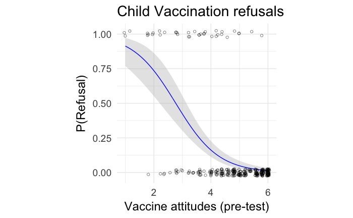

```r
# here's some sloppy code to plot that model
model <- glm(refuse ~ pretest,
  data = d_sum_behavior,
  family=binomial) #etc
temp.data <- data.frame(
  pretest =  seq(from=1, to = 6, length.out = 300))
temp.data <- cbind(temp.data, predict(model, temp.data, type = "link", se.fit=TRUE))
temp.data <- within(temp.data, {
  yHat <- model$family$linkinv(fit)
  LL <- model$family$linkinv(fit - 1.96 * se.fit)
  UL <- model$family$linkinv(fit + 1.96 * se.fit)
})
plt.refuse <- ggplot(temp.data, aes(x = pretest, y = yHat)) +
  geom_ribbon(aes(ymin = LL, ymax = UL), fill="grey", alpha = .4) +
  geom_line(colour = "blue") +
  labs(x = "Vaccine attitudes (pre-test)", y = "P(Refusal)", title="Child Vaccination refusals") +
  geom_jitter(data=d_sum_behavior,
              aes(x=pretest, y=refuse),
              inherit.aes = FALSE,
              height=.025,
              width=.05,
              alpha=.5,
              shape=1) +
  theme_minimal(base_size = 18) +
  theme(aspect.ratio = 1)
plt.refuse
```

## Parents vs non-parents

How many Ps are parents?

```r
d %>%
  group_by(condition, workerId) %>%
  summarize(parent = first(parent)) %>%
  summarize(prop_parent = mean(parent))
```

| condition | prop_parent |
| --- | --- |
| Control | 0.4180328 |
| Autism Correction | 0.4805195 |
| Disease Risk | 0.4260870 |

```r
NA
```

Looks like approximately 44-45% of participants are parents. Let’s see how the age of their youngest children breaks down.

```r
d <- d %>%
  mutate(youngest = as.numeric(as.character(youngest)),
         oldest = as.numeric(as.character(oldest)),
         youngest = ifelse(num_child==1,oldest,youngest))
```

```
NAs introduced by coercionNAs introduced by coercion
```

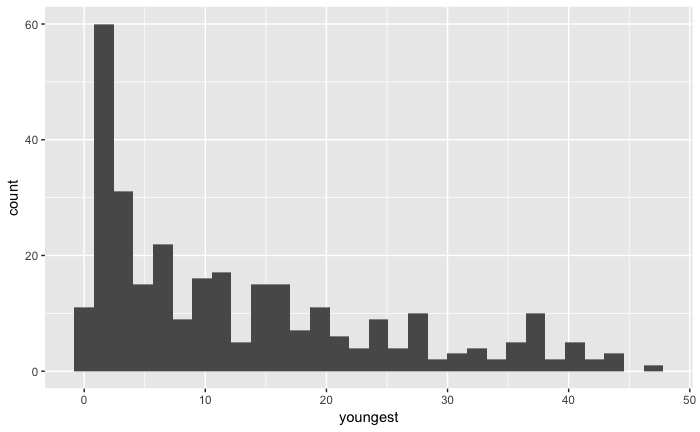

```r
d %>%
  group_by(workerId) %>%
  summarize(youngest = mean(youngest)) %>%
  ggplot(aes(x=youngest)) +
  geom_histogram()
```

And how many are planning to become parents soon?

- 0 = no
- 1 = Yes, in next 1-2 years
- 2 = Yes, in next 2-5 years
- 3 = yes, but not for 5 or more years

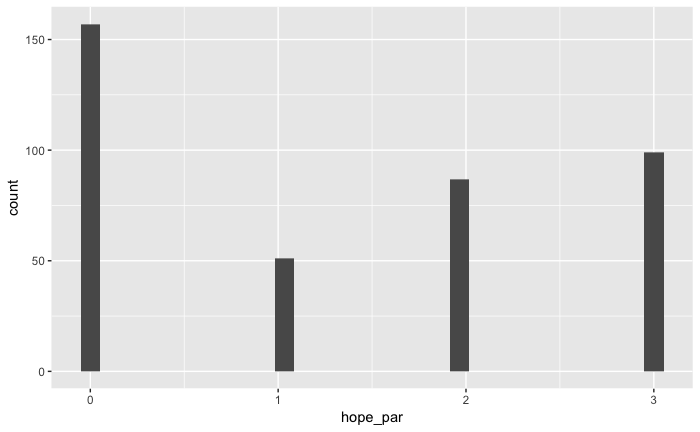

```r
d %>%
  group_by(workerId) %>%
  summarize(hope_par = first(hope_par)) %>%
  ggplot(aes(x=hope_par)) +
  geom_histogram()
```

Here we can focus in on the primary demographic of our interventions, parents of young children and those who are soon to be parents. Below, we code as `young_parent` parents with children under 12 and people who hope to become parents within the next 2 years.

```r
d_sum_pars <- d %>%
  filter(Scale=="vaxAttitude") %>%
  mutate(young_parent = ifelse( ((parent == 1 & youngest < 12) | (parent == 0 & hope_par == 1)), 1, 0 )) %>%
  mutate(young_parent = ifelse(is.na(young_parent),0,young_parent)) %>%
  group_by(workerId, condition, phase) %>%
  summarize(mean_rating = mean(rating),
            young_parent = first(young_parent)) %>%
  spread(phase, mean_rating) %>%
  mutate(change = posttest - pretest)
fit_beta_pars <- betareg(rescale_beta(posttest,1,6) ~ scale(pretest) + condition*young_parent,
           data=d_sum_pars)
summary(fit_beta_pars)
```

```
Call:
betareg(formula = rescale_beta(posttest, 1, 6) ~ scale(pretest) + condition * young_parent,
    data = d_sum_pars)

Standardized weighted residuals 2:
    Min      1Q  Median      3Q     Max
-3.2703 -0.6445 -0.2668  0.6961  4.8772

Coefficients (mean model with logit link):
                                        Estimate Std. Error z value Pr(>|z|)
(Intercept)                              1.60043    0.06546  24.447   <2e-16 ***
scale(pretest)                           1.14376    0.03369  33.949   <2e-16 ***
conditionAutism Correction               0.04373    0.09050   0.483   0.6290
conditionDisease Risk                    0.23019    0.09256   2.487   0.0129 *
young_parent                             0.12900    0.11187   1.153   0.2489
conditionAutism Correction:young_parent -0.03011    0.16522  -0.182   0.8554
conditionDisease Risk:young_parent      -0.04643    0.16240  -0.286   0.7749

Phi coefficients (precision model with identity link):
      Estimate Std. Error z value Pr(>|z|)
(phi)   7.7906     0.4398   17.71   <2e-16 ***
---
Signif. codes:  0 '***' 0.001 '**' 0.01 '*' 0.05 '.' 0.1 ' ' 1

Type of estimator: ML (maximum likelihood)
Log-likelihood:   991 on 8 Df
Pseudo R-squared: 0.5185
Number of iterations: 15 (BFGS) + 3 (Fisher scoring)
```

No significant effects of parenthood nor interactions with condition effects.

## Effect of autism correction condition on “autism” item

All told, the Autism Correction condition did not affect overall vaccine attitudes. However, it did clearly reduce agreement with the added item “Some vaccines cause autism in healthy children” (as found originally). So, it’s possible that people accept the information in the condiiton, but that it is only a very small part of what drives their overall attitudes toward vaccination.

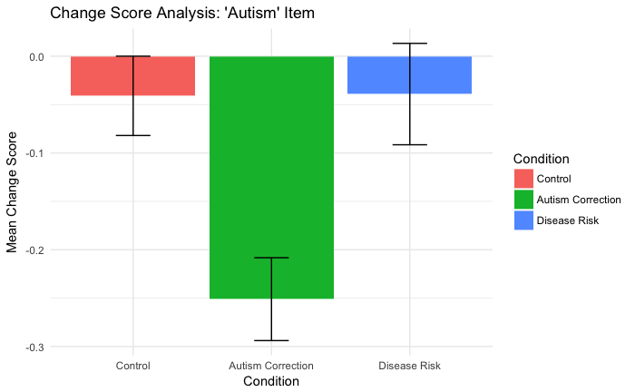

```r
d %>%
  filter(Scale=="autism") %>%
  group_by(workerId, condition, phase) %>%
  summarize(mean_rating = mean(rating)) %>%
  spread(phase, mean_rating) %>%
  summarize(change_score = posttest-pretest) %>%
  group_by(condition) %>%
  summarize(mean_change = mean(change_score),
            ul = mean(change_score) + stderr(change_score),
            ll = mean(change_score) - stderr(change_score)) %>%
  ggplot(aes(x=condition, fill=condition, y = mean_change, ymin=ll, ymax=ul)) +
  geom_bar(stat="identity") +
  geom_errorbar(width=.25) +
  theme_minimal() +
  labs(title="Change Score Analysis: 'Autism' Item",
       y = "Mean Change Score",
       x = "Condition",
       fill = "Condition")
```

# Summary

This study successfully replicated the original findings of the *PNAS* paper according to both its “direct replication” criterion and the “best model” criterion. The “disease risk” manipulation significantly improved attitudes toward vaccines as measured by the 5-item “vaccine attitudes” scale. The intervention also increased participants’ reported intentions to vaccinate their children, as measured by our new 5-item “vaccine intentions” scale.

### Miscellany

A participante noticed a typo in the “confident” vaccine Intent item, it said “… in the right thing to do” when it should have said “… is the right thing to do”.

(crude) Power analysis for future intervention studies below (April 23, 2018):

```r
power.t.test(delta = eff_size[4], power = .80)
```

```
     Two-sample t test power calculation

              n = 313.9374
          delta = 0.223957
             sd = 1
      sig.level = 0.05
          power = 0.8
    alternative = two.sided

NOTE: n is number in *each* group
```

### Replication notes

Analyses can be replicated using `derekpowell/rstudio-dmp:20180321` Docker image.